# Fetal Brain MeDIP Analysis Summary

Gloria Li  
Updated: Mon Dec 1 16:47:02 2014

## DMR analysis from MeDIP fractional calls

- DM CpG identification:
  - delta fractional methylation $\ge$ 0.6
  - fractional methylation of one sample $\ge$ 0.75
- Collapse DM CpGs into DMRs:
  - adjacent CpGs have the same DM status;
  - distance between adjacent CpGs $\le$ 300bp;
  - No. of CpGs within each DMR $\ge$ 4.

## DMRs between neurospheres Cortex and GE derived

### Summary and sanity check

- On average, there are **2451** Cortex UMRs, and **1686** GE UMRs. There seems to be an asymmetry between Cortex UMRs and GE UMRs.
- Median DMR length is **105**, *much smaller than WGBS*. It’s similar in all chromosomes.
- Median No. of CpGs per DMR is **6**, *larger than WGBS*. Also doesn’t fluctuate across chromosomes.

| Sample | Total.DMR | Hyper.DMR | Hypo.DMR |
| --- | --- | --- | --- |
| Cortex-HuFNSC01_GE-HuFNSC01 | 3228 | 1474 | 1754 |
| Cortex-HuFNSC02_GE-HuFNSC02 | 5047 | 1899 | 3148 |

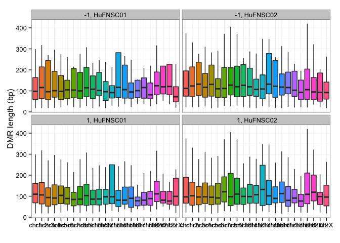

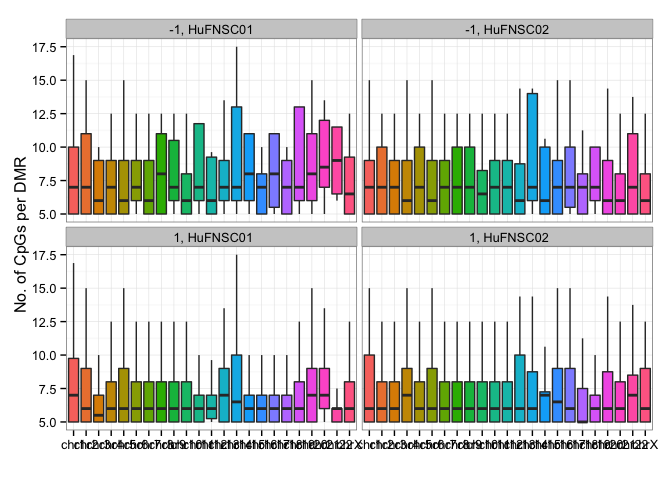

### Asymmetry between Cortex UMRs and GE UMRs

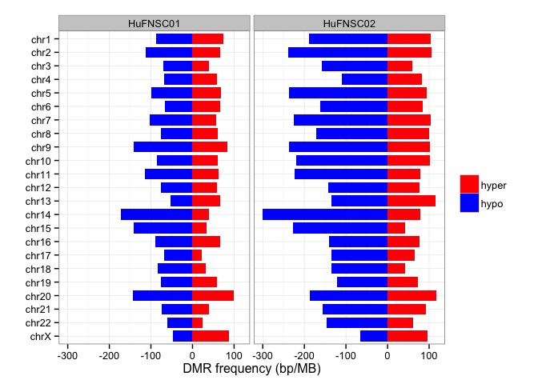

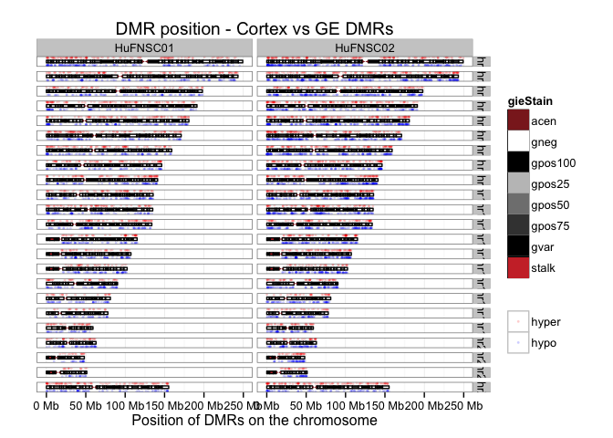

### GREAT analysis on Cortex UMRs and GE UMRs

- UMRs in both Cortex and GE in both individuals show enrichment in **neuron fate commitment** biological process, **transcriptional regulation** activities, **Homeobox** protein domain, and **abnormal brain development** mouse phenotype.
- Cortex UMRs are also enriched in **forebrain regionalization** and **pattern specification** processes.

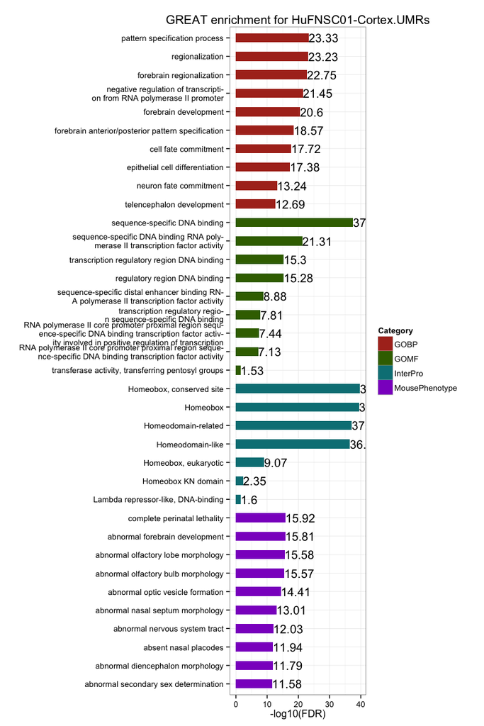

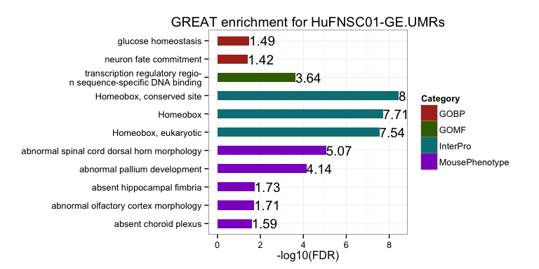

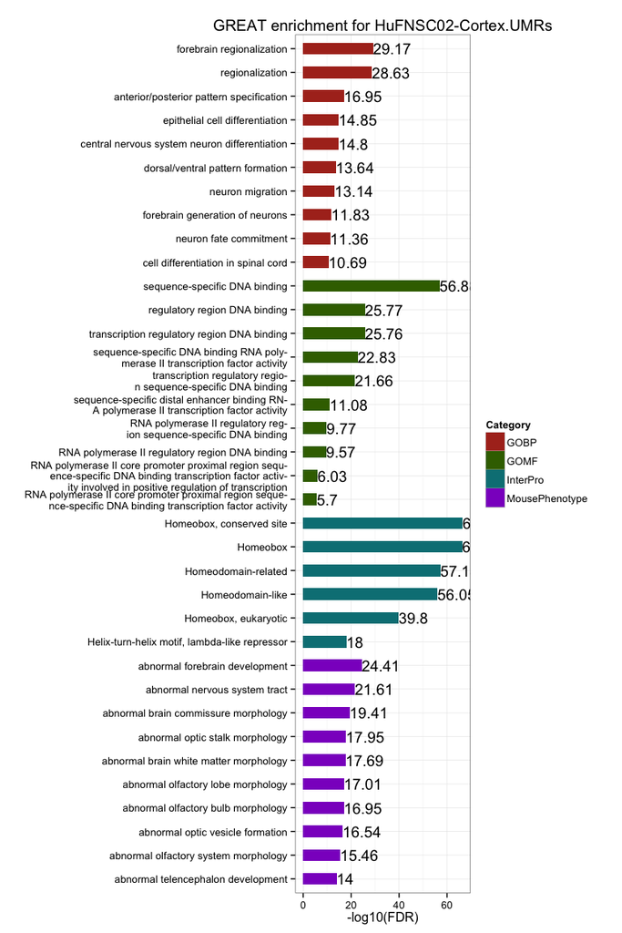

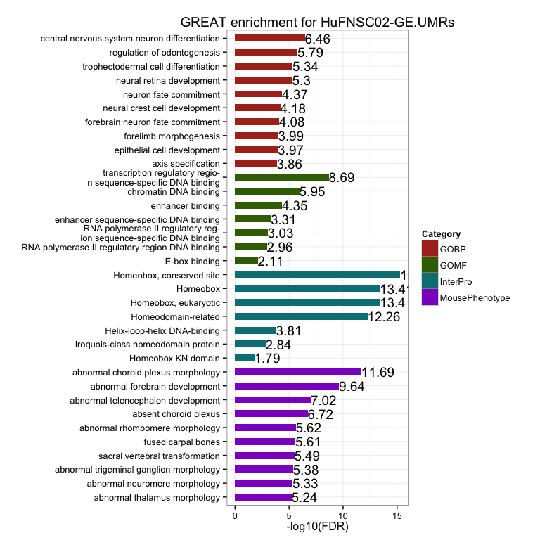

### UMR genomic break down

- UMRs are **2.44-fold** enriched in promoters, *higher than WGBS*, and **6.23-fold** enriched in CGIs, *slightly higher than WGBS*.

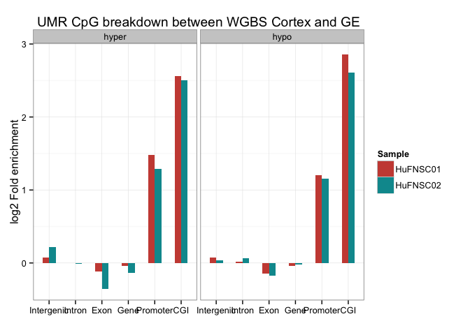

### Proximal UMRs and DE genes

- On average, there are **490** UMRs proximally (TSS +/- 1500bp) associated with protein-coding genes, **11.85%** of all UMRs, *higher than WGBS*.
- On average, there are **68** proximal UMRs associated with DE genes, **13.91%** of all proximal UMRs, *slightly lower than WGBS*. Among them, there are **57.59%** unique DE genes change in the same direction as the UMRs, *higher than WGBS*.
- The intersect between two individuals are **significant**.

|  | DMRs | unique.genes | DE.DMRs | unique.DE.genes | same.direction |
| --- | --- | --- | --- | --- | --- |
| GE01.UMRs | 419 | 466 | 35 | 35 | 20 |
| Cortex01.UMRs | 393 | 400 | 70 | 67 | 37 |
| GE02.UMRs | 461 | 501 | 60 | 58 | 31 |
| Cortex02.UMRs | 689 | 723 | 108 | 97 | 60 |

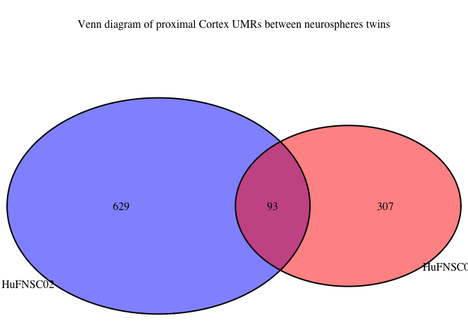

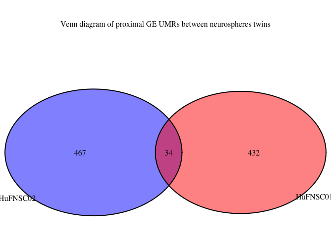

#### Cortex UMRs proximal associated DE genes

| name | description | DM | DE |
| --- | --- | --- | --- |
| BMP8B | bone_morphogenetic_protein_8b | hypo | DN |
| NOS1AP | nitric_oxide_synthase_1_(neuronal)*adaptor*protein | hypo | UP |
| SFMBT2 | Scm-like_with_four_mbt_domains_2 | hypo | DN |
| VAX1 | ventral_anterior_homeobox_1 | hypo | DN |
| RIC3 | resistance_to_inhibitors_of_cholinesterase_3_homolog_(C._elegans) | hypo | DN |
| TCIRG1 | T-cell,*immune*regulator_1,*ATPase,*H+*transporting,*lysosomal_V0_subunit_A3 | hypo | UP |
| TFCP2 | transcription_factor_CP2 | hypo | UP |
| SIAH3 | seven_in_absentia_homolog_3_(Drosophila) | hypo | DN |
| NKX2-1 | NK2_homeobox_1 | hypo | DN |
| ID2 | inhibitor_of_DNA_binding_2,*dominant*negative_helix-loop-helix_protein | hypo | UP |
| OTX1 | orthodenticle_homeobox_1 | hypo | UP |
| CYP27A1 | cytochrome_P450,*family*27,*subfamily*A,*polypeptide*1 | hypo | UP |
| CXCR7 | chemokine_(C-X-C_motif)*receptor*7 | hypo | DN |
| FEZF2 | FEZ_family_zinc_finger_2 | hypo | UP |
| CYTL1 | cytokine-like_1 | hypo | DN |
| IRX2 | iroquois_homeobox_2 | hypo | DN |
| PDGFA | platelet-derived_growth_factor_alpha_polypeptide | hypo | DN |
| SH3KBP1 | SH3-domain_kinase_binding_protein_1 | hypo | UP |

#### GE UMRs proximal associated DE genes

| name | description | DM | DE |
| --- | --- | --- | --- |
| C10orf90 | chromosome_10_open_reading_frame_90 | hyper | DN |
| TMEM132B | transmembrane_protein_132B | hyper | UP |
| PRDM1 | PR_domain_containing_1,*with*ZNF_domain | hyper | DN |

### Overlap UMRs with TFBSs

- Overlap UMRs with transcription factor binding sites and count No. of overlapping TFBSs for each TF showed different asymmetry in Cortex and GE.
- HuFNSC02 show similar trend as WGBS, with TFBSs enriched in Cortex UMRs for most TFs, and top TFs with highest fold cahnge in No. of TFBS between Cortex and GE have overlaps with WGBS, such as GATA2, FOXA1, ZNF217.
- However, HuFNSC01 showed the opposite trend, with most TFs enriched in GE. *Why?* In general, the correlation of TFBS Cortex UMR vs GE UMR fold change between the two individual is quite low, 0.21, *similar to WGBS*. Maybe TFBSs trend is individual-specific.
- With 1.5-fold change cutoff, there are 6 TFs enriched in Cortex UMRs in both individuals, and 4 in GE UMRs.

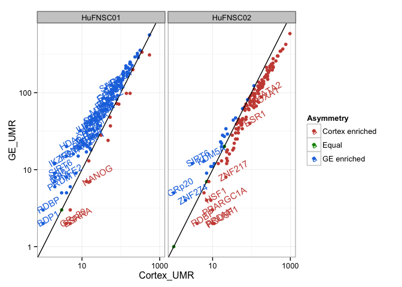

| TF | Cortex01UMR | GE01UMR | Ratio01 | Cortex02UMR | GE02UMR | Ratio02 |
| --- | --- | --- | --- | --- | --- | --- |
| SUZ12 | 173 | 98 | 1.77 | 256 | 160 | 1.60 |
| EZH2 | 546 | 309 | 1.77 | 764 | 424 | 1.80 |
| ZNF217 | 13 | 7 | 1.86 | 22 | 8 | 2.75 |
| ESR1 | 47 | 24 | 1.96 | 91 | 40 | 2.27 |
| NANOG | 16 | 7 | 2.29 | 23 | 12 | 1.92 |
| ESRRA | 5 | 2 | 2.50 | 7 | 4 | 1.75 |

| TF | Cortex01UMR | GE01UMR | Ratio01 | Cortex02UMR | GE02UMR | Ratio02 |
| --- | --- | --- | --- | --- | --- | --- |
| SIRT6 | 2 | 9 | 0.22 | 3 | 12 | 0.25 |
| KDM5A | 4 | 15 | 0.27 | 6 | 13 | 0.46 |
| ATF1 | 16 | 33 | 0.48 | 22 | 34 | 0.65 |
| SP2 | 11 | 22 | 0.50 | 18 | 28 | 0.64 |

## DMRs between monozygptic twins

### Summary and sanity check

| Sample | Total.DMR | Hyper.DMR | Hypo.DMR |
| --- | --- | --- | --- |
| Brain-HuFNSC01_Brain-HuFNSC02 | 4472 | 2750 | 1722 |
| Cortex-HuFNSC01_Cortex-HuFNSC02 | 3161 | 1758 | 1403 |
| GE-HuFNSC01_GE-HuFNSC02 | 2716 | 1136 | 1580 |

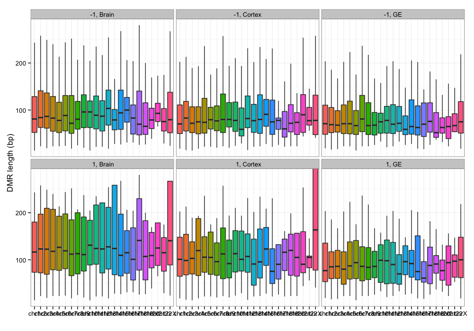

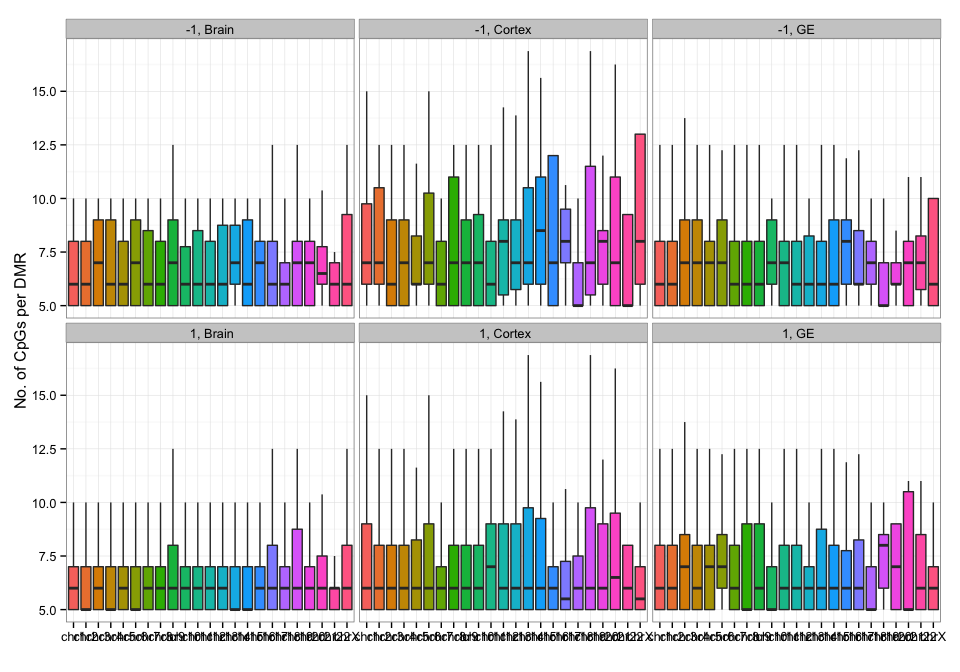

### Asymmetry between MZ twins

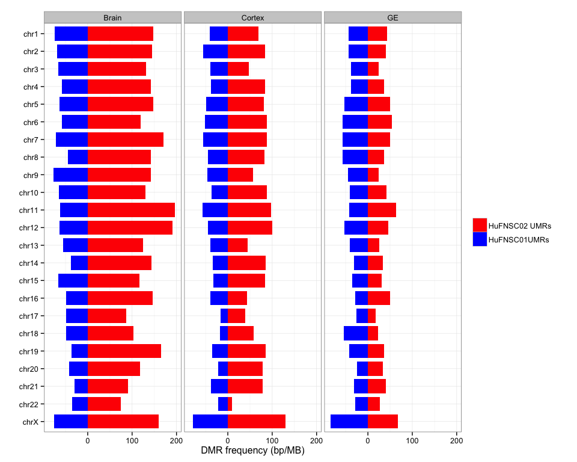

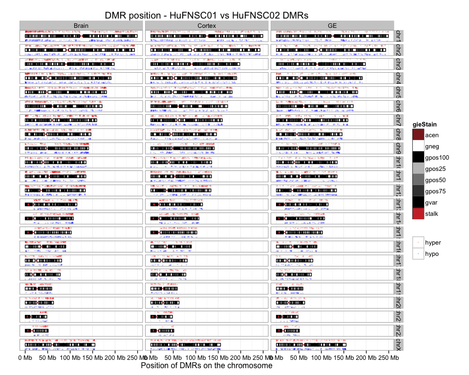

### GREAT analysis on MZ UMRs

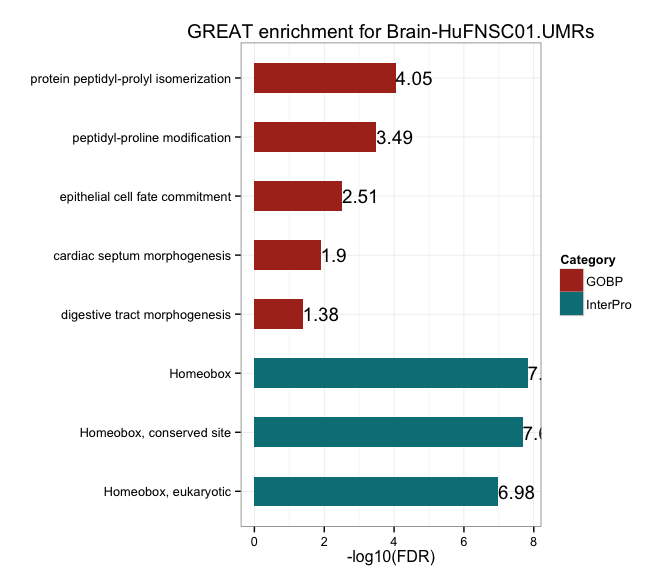

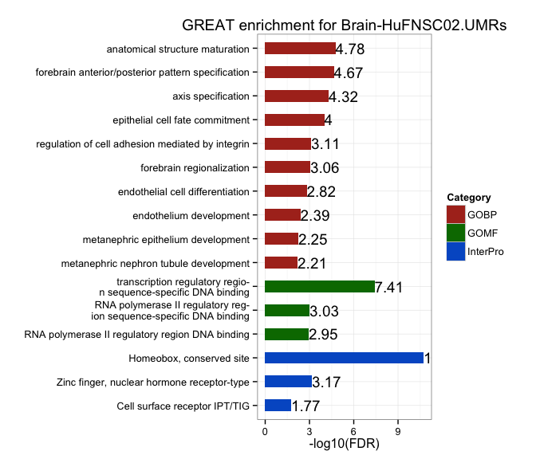

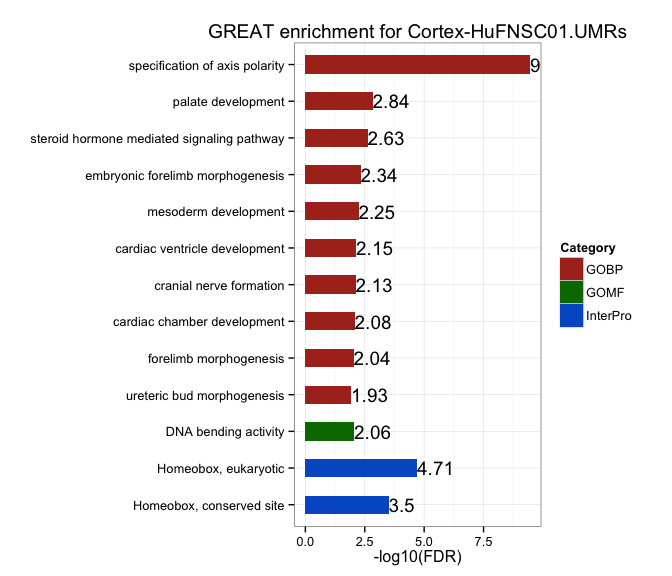

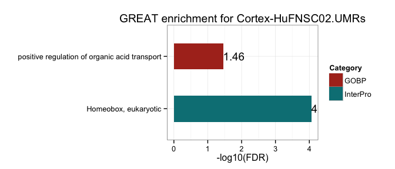

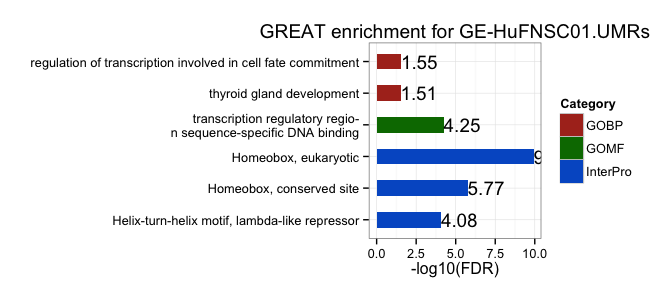

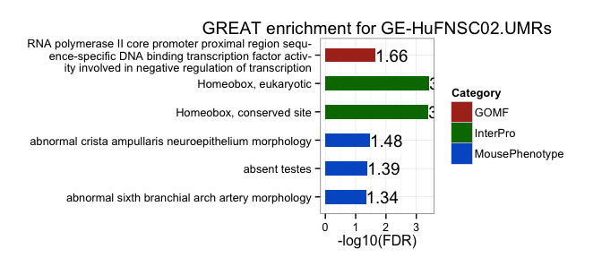

### MZ UMR breakdown

- UMR CpGs are **2.6-fold** enriched in promoter regions, and **5.34-fold** enriched in CGIs.
- Brain seems to have less CGI/promoter UMRs.

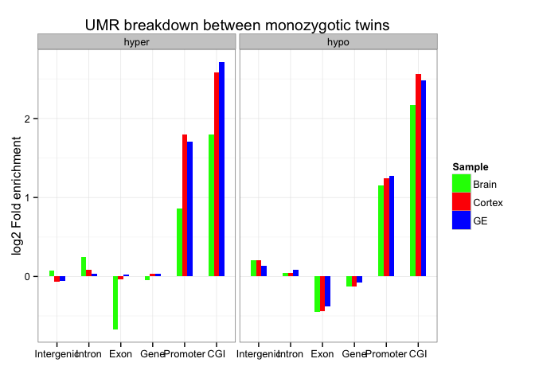

### Proximal UMRs and DE genes

- On average, there are **405** UMRs proximally (TSS +/- 1500bp) associated with protein-coding genes, **11.75%** of all UMRs, *similar to UMRs between Cortex and GE*.
- On average, there are **17** proximal UMRs associated with DE genes, **4.24%** of all proximal DMRs, *much less than UMRs between Cortex and GE (less functional?)*. Among them, there are **52.53%** unique DE genes change in the same direction as the UMRs, *similar to UMRs between Cortex and GE*.
- Proximal UMR genes are mostly **cell type specific**, but the overlap is still statistically significant.
- No overlap between Brain and Cortex for proximal HuFNSC01 UMR DE genes, only one for HuFNSC02, **neuropeptide_Y**.

|  | DMRs | unique.genes | DE.DMRs | unique.DE.genes | same.direction |
| --- | --- | --- | --- | --- | --- |
| Brain01_Brain02_hyper | 432 | 473 | 26 | 26 | 10 |
| Brain01_Brain02_hypo | 367 | 409 | 20 | 20 | 13 |
| Cortex01_Cortex02_hyper | 587 | 659 | 30 | 28 | 17 |
| Cortex01_Cortex02_hypo | 316 | 342 | 24 | 22 | 11 |
| GE01_GE02_hyper | 369 | 402 | 1 | 1 | 1 |
| GE01_GE02_hypo | 361 | 398 | 2 | 2 | 0 |

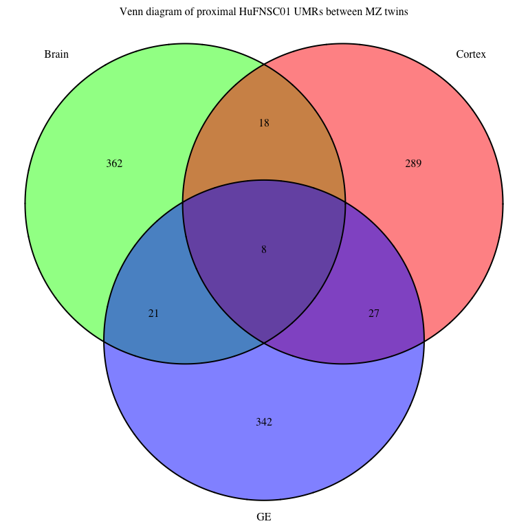

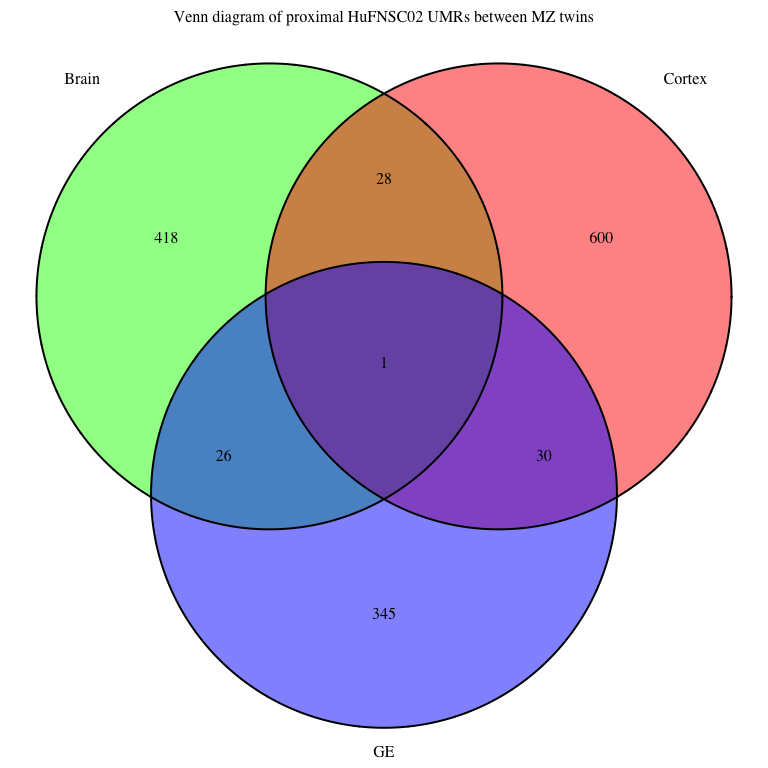

#### HuFNSC01 UMRs proximal associated DE genes

| CellType | name | description | DM | DE |
| --- | --- | --- | --- | --- |
| Brain | SAMD11 | sterile_alpha_motif_domain_containing_11 | hypo | UP |
| Brain | ITGA8 | integrin,*alpha*8 | hypo | UP |
| Brain | EMX2 | empty_spiracles_homeobox_2 | hypo | DN |
| Brain | ARNTL2 | aryl_hydrocarbon_receptor_nuclear_translocator-like_2 | hypo | UP |
| Brain | CPNE8 | copine_VIII | hypo | DN |
| Brain | PCDH17 | protocadherin_17 | hypo | DN |
| Brain |  | Putative_3-phosphoinositide-dependent_protein_kinase_2 | hypo | UP |
| Brain | CPNE7 | copine_VII | hypo | UP |
| Brain | PKDREJ | polycystic_kidney_disease_(polycystin)*and*REJ_homolog_(sperm_receptor_for_egg_jelly_homolog,*sea*urchin) | hypo | UP |
| Brain | THRB | thyroid_hormone_receptor,_beta | hypo | UP |
| Brain | SFRP2 | secreted_frizzled-related_protein_2 | hypo | DN |
| Brain | IER3 | immediate_early_response_3 | hypo | UP |
| Brain | ZBTB12 | zinc_finger_and_BTB_domain_containing_12 | hypo | UP |
| Brain | MDGA1 | MAM_domain_containing_glycosylphosphatidylinositol_anchor_1 | hypo | DN |
| Brain | EPHA1 | EPH_receptor_A1 | hypo | UP |
| Brain |  | Protein_kinase-like_protein_SgK196 | hypo | UP |
| Brain | TOX | thymocyte_selection-associated_high_mobility_group_box | hypo | DN |
| Brain | NCOA2 | nuclear_receptor_coactivator_2 | hypo | UP |
| Brain | GPR64 | G_protein-coupled_receptor_64 | hypo | UP |
| Brain | TRPC5 | transient_receptor_potential_cation_channel,*subfamily*C,*member*5 | hypo | DN |
| Cortex | ELTD1 | EGF,*latrophilin*and_seven_transmembrane_domain_containing_1 | hypo | UP |
| Cortex | CRABP2 | cellular_retinoic_acid_binding_protein_2 | hypo | DN |
| Cortex | SPOCK2 | sparc/osteonectin,*cwcv*and_kazal-like_domains_proteoglycan_(testican)_2 | hypo | DN |
| Cortex | VAX1 | ventral_anterior_homeobox_1 | hypo | UP |
| Cortex | LRRC10B | leucine_rich_repeat_containing_10B | hypo | DN |
| Cortex | NDUFA4L2 | NADH_dehydrogenase_(ubiquinone)*1*alpha_subcomplex,*4-like*2 | hypo | DN |
| Cortex | FOXO1 | forkhead_box_O1 | hypo | UP |
| Cortex | C16orf74 | chromosome_16_open_reading_frame_74 | hypo | DN |
| Cortex | WNT3 | wingless-type_MMTV_integration_site_family,*member*3 | hypo | DN |
| Cortex | CHST9 | carbohydrate_(N-acetylgalactosamine_4-0)*sulfotransferase*9 | hypo | UP |
| Cortex | CD97 | CD97_molecule | hypo | DN |
| Cortex | RNF144A | ring_finger_protein_144A | hypo | UP |
| Cortex | DLX1 | distal-less_homeobox_1 | hypo | UP |
| Cortex | OLIG1 | oligodendrocyte_transcription_factor_1 | hypo | UP |
| Cortex | SCUBE1 | signal_peptide,*CUB*domain,*EGF-like*1 | hypo | DN |
| Cortex | GRIA1 | glutamate_receptor,*ionotropic,*AMPA_1 | hypo | DN |
| Cortex | MMD2 | monocyte_to_macrophage_differentiation-associated_2 | hypo | UP |
| Cortex | SEMA3E | sema_domain,*immunoglobulin*domain_(Ig),*short*basic_domain,*secreted,*(semaphorin)_3E | hypo | DN |
| Cortex | VIPR2 | vasoactive_intestinal_peptide_receptor_2 | hypo | DN |
| Cortex | AP1S2 | adaptor-related_protein_complex_1,*sigma*2_subunit | hypo | DN |
| Cortex | SH3KBP1 | SH3-domain_kinase_binding_protein_1 | hypo | UP |
| GE | FAM5B | family_with_sequence_similarity_5,*member*B | hypo | DN |
| GE | DLL1 | delta-like_1_(Drosophila) | hypo | DN |

#### HuFNSC02 UMRs proximal associated DE genes

| CellType | name | description | DM | DE |
| --- | --- | --- | --- | --- |
| Brain | EPHA8 | EPH_receptor_A8 | hyper | UP |
| Brain | IFI6 | interferon,*alpha-inducible*protein_6 | hyper | DN |
| Brain | BMP8A | bone_morphogenetic_protein_8a | hyper | UP |
| Brain | ALX3 | ALX_homeobox_3 | hyper | UP |
| Brain | NRGN | neurogranin_(protein_kinase_C_substrate,_RC3) | hyper | UP |
| Brain | C1QL4 | complement_component_1,*q*subcomponent-like_4 | hyper | UP |
| Brain | CSRP2 | cysteine_and_glycine-rich_protein_2 | hyper | DN |
| Brain | TTYH2 | tweety_homolog_2_(Drosophila) | hyper | DN |
| Brain | DTNB | dystrobrevin,_beta | hyper | UP |
| Brain | CXCR7 | chemokine_(C-X-C_motif)*receptor*7 | hyper | UP |
| Brain | VHL | von_Hippel-Lindau_tumor_suppressor | hyper | UP |
| Brain | EPHA6 | EPH_receptor_A6 | hyper | UP |
| Brain | CAMK2N2 | calcium/calmodulin-dependent_protein_kinase_II_inhibitor_2 | hyper | UP |
| Brain | TBC1D1 | TBC1_(tre-2/USP6,*BUB2,*cdc16)*domain*family,*member*1 | hyper | DN |
| Brain | NMU | neuromedin_U | hyper | DN |
| Brain | FSTL5 | follistatin-like_5 | hyper | DN |
| Brain | CARTPT | CART_prepropeptide | hyper | DN |
| Brain | EDIL3 | EGF-like_repeats_and_discoidin_I-like_domains_3 | hyper | UP |
| Brain | CCDC90A | coiled-coil_domain_containing_90A | hyper | UP |
| Brain |  | LOC401296_proteinUncharacterized_protein | hyper | UP |
| Brain | NPY | neuropeptide_Y | hyper | UP |
| Brain | SFRP1 | secreted_frizzled-related_protein_1 | hyper | DN |
| Brain | TOX | thymocyte_selection-associated_high_mobility_group_box | hyper | DN |
| Brain | ENTPD2 | ectonucleoside_triphosphate_diphosphohydrolase_2 | hyper | UP |
| Brain | KLHL4 | kelch-like_4_(Drosophila) | hyper | UP |
| Brain | SOX3 | SRY_(sex_determining_region_Y)-box_3 | hyper | DN |
| Cortex | DMRTA2 | DMRT-like_family_A2 | hyper | DN |
| Cortex | NPR1 | natriuretic_peptide_receptor_A/guanylate_cyclase_A_(atrionatriuretic_peptide_receptor_A) | hyper | UP |
| Cortex | PTPRE | protein_tyrosine_phosphatase,*receptor*type,_E | hyper | DN |
| Cortex | PDE3B | phosphodiesterase_3B,_cGMP-inhibited | hyper | UP |
| Cortex | LDHA | lactate_dehydrogenase_A | hyper | DN |
| Cortex | GNG3 | guanine_nucleotide_binding_protein_(G_protein),*gamma*3 | hyper | DN |
| Cortex | METTL7B | methyltransferase_like_7B | hyper | DN |
| Cortex | NME3 | non-metastatic_cells_3,*protein*expressed_in | hyper | DN |
| Cortex | GRIN2A | glutamate_receptor,*ionotropic,*N-methyl_D-aspartate_2A | hyper | UP |
| Cortex | NOL3 | nucleolar_protein_3_(apoptosis_repressor_with_CARD_domain) | hyper | DN |
| Cortex | NR1D1 | nuclear_receptor_subfamily_1,*group*D,*member*1 | hyper | DN |
| Cortex | IGFBP4 | insulin-like_growth_factor_binding_protein_4 | hyper | UP |
| Cortex | TBX2 | T-box_2 | hyper | UP |
| Cortex | LBH | limb_bud_and_heart_development_homolog_(mouse) | hyper | DN |
| Cortex | INSIG2 | insulin_induced_gene_2 | hyper | DN |
| Cortex | WNT7A | wingless-type_MMTV_integration_site_family,*member*7A | hyper | DN |
| Cortex | SNCA | synuclein,*alpha*(non_A4_component_of_amyloid_precursor) | hyper | UP |
| Cortex | NPNT | nephronectin | hyper | DN |
| Cortex | SFRP2 | secreted_frizzled-related_protein_2 | hyper | UP |
| Cortex | PRR16 | proline_rich_16 | hyper | UP |
| Cortex | STC2 | stanniocalcin_2 | hyper | DN |
| Cortex | SNCB | synuclein,_beta | hyper | DN |
| Cortex | ITPR3 | inositol_1,4,5-trisphosphate_receptor,*type*3 | hyper | UP |
| Cortex | NPY | neuropeptide_Y | hyper | DN |
| Cortex | SEMA3D | sema_domain,*immunoglobulin*domain_(Ig),*short*basic_domain,*secreted,*(semaphorin)_3D | hyper | UP |
| Cortex | VGF | VGF_nerve_growth_factor_inducible | hyper | UP |
| Cortex | CAV1 | caveolin_1,*caveolae*protein,_22kDa | hyper | UP |
| Cortex | SHROOM2 | shroom_family_member_2 | hyper | UP |
| GE | DBC1 | deleted_in_bladder_cancer_1 | hyper | DN |

### Overlap UMRs with TFBSs

- Overlap UMRs with transcription factor binding sites and count No. of overlapping TFBSs for each TF showed similar asymmetry in Brain and Cortex, but is symmetric in GE. The correlation between Brain and Cortex is also very low, **0.15**.
- With 2-fold change cutoff, there are 18 TFs enriched in HuFNSC02 in both Brain and Cortex.

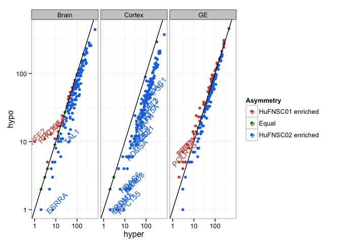

| TF | Brain.hypo | Brain.hyper | Ratio.Brain | Cortex.hypo | Cortex.hyper | Ratio.Cortex |
| --- | --- | --- | --- | --- | --- | --- |
| ESRRA | 1 | 7 | 0.14 | 1 | 5 | 0.20 |
| TAL1 | 10 | 42 | 0.24 | 9 | 34 | 0.26 |
| HNF4A | 15 | 49 | 0.31 | 11 | 27 | 0.41 |
| HNF4G | 13 | 41 | 0.32 | 10 | 29 | 0.34 |
| ZNF217 | 6 | 17 | 0.35 | 6 | 14 | 0.43 |
| EBF1 | 49 | 130 | 0.38 | 48 | 98 | 0.49 |
| FOS | 47 | 123 | 0.38 | 43 | 118 | 0.36 |
| GATA1 | 31 | 73 | 0.42 | 32 | 80 | 0.40 |
| HSF1 | 3 | 7 | 0.43 | 2 | 6 | 0.33 |
| FOXA2 | 26 | 60 | 0.43 | 14 | 36 | 0.39 |
| GATA3 | 35 | 80 | 0.44 | 22 | 52 | 0.42 |
| GATA2 | 58 | 130 | 0.45 | 39 | 96 | 0.41 |
| STAT3 | 41 | 91 | 0.45 | 26 | 87 | 0.30 |
| CEBPD | 22 | 48 | 0.46 | 23 | 64 | 0.36 |
| SMC3 | 71 | 150 | 0.47 | 62 | 144 | 0.43 |
| NR3C1 | 46 | 95 | 0.48 | 39 | 90 | 0.43 |
| RXRA | 23 | 47 | 0.49 | 16 | 35 | 0.46 |
| HDAC6 | 1 | 2 | 0.50 | 2 | 11 | 0.18 |